# Project: Investigate aTMDb-Movies Dataset

- Introduction
- Data Wrangling
- Exploratory Data Analysis
- Conclusions

## Introduction

I used Tmdb movies dataset to analsye and investigate data

QUESTIONS

From when Women centered movies are made?  
Which film has made the most money ever?  
Which genre of movies has been relatively preferred over the years?  
who are the most prefered Actors and Directors Before & After 2000?  
What are the top successfull movies with respect to runtime before and after 2000?

```python
# Use this cell to set up import statements for all of the packages that you
#   plan to use.

# Remember to include a 'magic word' so that your visualizations are plotted
#   inline with the notebook. See this page for more:
# http://ipython.readthedocs.io/en/stable/interactive/magics.html

import numpy as np
import pandas as pd
import matplotlib.pyplot as plot
import seaborn as sb
%matplotlib inline

#set ggplot style
plot.style.use('ggplot')
```

```python
t_data = pd.read_csv("movies.csv")
t_data.shape
```

```
(10866, 21)
```

## Data Wrangling

checking for cleanliness, and then trimming,cleaning dataset for analysis

### General Properties

```python
# Load your data and print out a few lines. Perform operations to inspect data
#   types and look for instances odata = pds.read_csv("titanic-data.csv")f missing or possibly errant dat
tdata = pd.read_csv("movies.csv")
tdata.shape
```

```
(10866, 21)
```

```python
tdata.head(2)
```

|  | id | imdb_id | popularity | budget | revenue | original_title | cast | homepage | director | tagline | ... | overview | runtime | genres | production_companies | release_date | vote_count | vote_average | release_year | budget_adj | revenue_adj |
| --- | --- | --- | --- | --- | --- | --- | --- | --- | --- | --- | --- | --- | --- | --- | --- | --- | --- | --- | --- | --- | --- |
| 0 | 135397 | tt0369610 | 32.985763 | 150000000 | 1513528810 | Jurassic World | Chris Pratt\|Bryce Dallas Howard\|Irrfan Khan\|Vi... | http://www.jurassicworld.com/ | Colin Trevorrow | The park is open. | ... | Twenty-two years after the events of Jurassic ... | 124 | Action\|Adventure\|Science Fiction\|Thriller | Universal Studios\|Amblin Entertainment\|Legenda... | 6/9/15 | 5562 | 6.5 | 2015 | 1.379999e+08 | 1.392446e+09 |
| 1 | 76341 | tt1392190 | 28.419936 | 150000000 | 378436354 | Mad Max: Fury Road | Tom Hardy\|Charlize Theron\|Hugh Keays-Byrne\|Nic... | http://www.madmaxmovie.com/ | George Miller | What a Lovely Day. | ... | An apocalyptic story set in the furthest reach... | 120 | Action\|Adventure\|Science Fiction\|Thriller | Village Roadshow Pictures\|Kennedy Miller Produ... | 5/13/15 | 6185 | 7.1 | 2015 | 1.379999e+08 | 3.481613e+08 |

2 rows × 21 columns

OBSERVATION

Given dataset contains 21 columns where currency has no unit.

```python
tdata.info()
```

```
<class 'pandas.core.frame.DataFrame'>
RangeIndex: 10866 entries, 0 to 10865
Data columns (total 21 columns):
id                      10866 non-null int64
imdb_id                 10856 non-null object
popularity              10866 non-null float64
budget                  10866 non-null int64
revenue                 10866 non-null int64
original_title          10866 non-null object
cast                    10790 non-null object
homepage                2936 non-null object
director                10822 non-null object
tagline                 8042 non-null object
keywords                9373 non-null object
overview                10862 non-null object
runtime                 10866 non-null int64
genres                  10843 non-null object
production_companies    9836 non-null object
release_date            10866 non-null object
vote_count              10866 non-null int64
vote_average            10866 non-null float64
release_year            10866 non-null int64
budget_adj              10866 non-null float64
revenue_adj             10866 non-null float64
dtypes: float64(4), int64(6), object(11)
memory usage: 1.7+ MB
```

### Data Cleansing

Removing unused columns

```python
# After discussing the structure of the data and any problems that need to be
#   cleaned, perform those cleaning steps in the second part of this section.
delcol=['id','imdb_id','homepage','tagline','overview','budget_adj','revenue_adj']
tdata=tdata.drop(delcol,axis=1)
tdata.head(2)
```

|  | popularity | budget | revenue | original_title | cast | director | keywords | runtime | genres | production_companies | release_date | vote_count | vote_average | release_year |
| --- | --- | --- | --- | --- | --- | --- | --- | --- | --- | --- | --- | --- | --- | --- |
| 0 | 32.985763 | 150000000 | 1513528810 | Jurassic World | Chris Pratt\|Bryce Dallas Howard\|Irrfan Khan\|Vi... | Colin Trevorrow | monster\|dna\|tyrannosaurus rex\|velociraptor\|island | 124 | Action\|Adventure\|Science Fiction\|Thriller | Universal Studios\|Amblin Entertainment\|Legenda... | 6/9/15 | 5562 | 6.5 | 2015 |
| 1 | 28.419936 | 150000000 | 378436354 | Mad Max: Fury Road | Tom Hardy\|Charlize Theron\|Hugh Keays-Byrne\|Nic... | George Miller | future\|chase\|post-apocalyptic\|dystopia\|australia | 120 | Action\|Adventure\|Science Fiction\|Thriller | Village Roadshow Pictures\|Kennedy Miller Produ... | 5/13/15 | 6185 | 7.1 | 2015 |

Removing Duplicates

```python
tdata.drop_duplicates(keep ='first', inplace=True)
```

```python
 tdata.shape
```

```
(10865, 14)
```

Detect Missing values

```python
tdata.isnull().sum()
```

```
popularity                 0
budget                     0
revenue                    0
original_title             0
cast                      76
director                  44
keywords                1493
runtime                    0
genres                    23
production_companies    1030
release_date               0
vote_count                 0
vote_average               0
release_year               0
dtype: int64
```

Replacing zero with NAN and Dropping the rows contains NAN

```python
# creating a seperate list
temp=['budget', 'revenue','keywords','director']
tdata[temp] = tdata[temp].replace(0, np.NAN)
tdata.dropna(subset = temp, inplace = True)
tdata.shape
```

```
(3716, 14)
```

Change format of release_date

```python
tdata.release_date = pd.to_datetime(tdata['release_date'])
tdata.head(2)
```

|  | popularity | budget | revenue | original_title | cast | director | keywords | runtime | genres | production_companies | release_date | vote_count | vote_average | release_year |
| --- | --- | --- | --- | --- | --- | --- | --- | --- | --- | --- | --- | --- | --- | --- |
| 0 | 32.985763 | 150000000.0 | 1.513529e+09 | Jurassic World | Chris Pratt\|Bryce Dallas Howard\|Irrfan Khan\|Vi... | Colin Trevorrow | monster\|dna\|tyrannosaurus rex\|velociraptor\|island | 124 | Action\|Adventure\|Science Fiction\|Thriller | Universal Studios\|Amblin Entertainment\|Legenda... | 2015-06-09 | 5562 | 6.5 | 2015 |
| 1 | 28.419936 | 150000000.0 | 3.784364e+08 | Mad Max: Fury Road | Tom Hardy\|Charlize Theron\|Hugh Keays-Byrne\|Nic... | George Miller | future\|chase\|post-apocalyptic\|dystopia\|australia | 120 | Action\|Adventure\|Science Fiction\|Thriller | Village Roadshow Pictures\|Kennedy Miller Produ... | 2015-05-13 | 6185 | 7.1 | 2015 |

## Exploratory Data Analysis

### Trend of Women Centered Movies

```python
tdata[tdata['keywords'].str.match('women','feminism')]
```

|  | popularity | budget | revenue | original_title | cast | director | keywords | runtime | genres | production_companies | release_date | vote_count | vote_average | release_year |
| --- | --- | --- | --- | --- | --- | --- | --- | --- | --- | --- | --- | --- | --- | --- |
| 1561 | 0.534693 | 3000000.0 | 18097.0 | Women in Trouble | Carla Gugino\|Adrianne Palicki\|Connie Britton\|M... | Sebastian Gutierrez | women\|infidelity\|stewardess\|aftercreditsstinger | 92 | Comedy\|Drama | Gato Negro Films | 2009-11-13 | 11 | 4.5 | 2009 |
| 1982 | 1.146440 | 10000000.0 | 2995811.0 | The Runaways | Dakota Fanning\|Kristen Stewart\|Michael Shannon... | Floria Sigismondi | women\|1970s\|publicity\|iron\|music | 106 | Drama\|Music | River Road Entertainment\|Road Rebel\|Linson Ent... | 2010-03-19 | 133 | 6.3 | 2010 |
| 2678 | 0.945429 | 42000000.0 | 35402320.0 | Original Sin | Angelina Jolie\|Antonio Banderas\|Gregory Itzin\|... | Michael Cristofer | women\|sex\|cuba\|eroticism\|lover (female) | 118 | Drama\|Thriller\|Mystery\|Romance | Metro-Goldwyn-Mayer (MGM) | 2001-08-03 | 115 | 5.8 | 2001 |
| 5468 | 1.765514 | 5000000.0 | 55198285.0 | Dallas Buyers Club | Matthew McConaughey\|Jennifer Garner\|Jared Leto... | Jean-Marc Vallée | women\|aids\|biography\|based on true story\|hiv | 117 | Drama\|History | Universal Studios\|Universal Pictures\|Voltage P... | 2013-09-07 | 1831 | 7.8 | 2013 |
| 7397 | 2.400727 | 25000000.0 | 25037897.0 | Death Proof | Kurt Russell\|Zoë Bell\|Rosario Dawson\|Vanessa ... | Quentin Tarantino | women\|disc jockey\|sports car\|bar\|ladykiller | 113 | Action\|Thriller | The Weinstein Company\|Dimension Films\|Troublem... | 2007-05-21 | 720 | 6.7 | 2007 |
| 8670 | 1.767681 | 70000000.0 | 374111707.0 | What Women Want | Helen Hunt\|Mel Gibson\|Marisa Tomei\|Lauren Holl... | Nancy Meyers | women\|telepathy\|supernatural powers\|advertisin... | 127 | Comedy\|Romance | Paramount Pictures\|Centropolis Entertainment\|I... | 2000-12-14 | 576 | 6.0 | 2000 |

Female centric movies has been directed and released from the year 2000. It indicates a paradigm shift for women in American Film society.

```python
#Inserting profit column(profit=revenue-budget)
tdata.insert(1,'profit',tdata['revenue']-tdata['budget'])
tdata.head(2)
```

|  | popularity | profit | budget | revenue | original_title | cast | director | keywords | runtime | genres | production_companies | release_date | vote_count | vote_average | release_year |
| --- | --- | --- | --- | --- | --- | --- | --- | --- | --- | --- | --- | --- | --- | --- | --- |
| 0 | 32.985763 | 1.363529e+09 | 150000000.0 | 1.513529e+09 | Jurassic World | Chris Pratt\|Bryce Dallas Howard\|Irrfan Khan\|Vi... | Colin Trevorrow | monster\|dna\|tyrannosaurus rex\|velociraptor\|island | 124 | Action\|Adventure\|Science Fiction\|Thriller | Universal Studios\|Amblin Entertainment\|Legenda... | 2015-06-09 | 5562 | 6.5 | 2015 |
| 1 | 28.419936 | 2.284364e+08 | 150000000.0 | 3.784364e+08 | Mad Max: Fury Road | Tom Hardy\|Charlize Theron\|Hugh Keays-Byrne\|Nic... | George Miller | future\|chase\|post-apocalyptic\|dystopia\|australia | 120 | Action\|Adventure\|Science Fiction\|Thriller | Village Roadshow Pictures\|Kennedy Miller Produ... | 2015-05-13 | 6185 | 7.1 | 2015 |

### Highest Profit

```python
# High profit
high_profit=tdata['profit'].idxmax()
high_details=pd.DataFrame(tdata.loc[high_profit])
print(high_details)
```

```
                                                                   1386
popularity                                                      9.43277
profit                                                      2.54451e+09
budget                                                         2.37e+08
revenue                                                     2.78151e+09
original_title                                                   Avatar
cast                  Sam Worthington|Zoe Saldana|Sigourney Weaver|S...
director                                                  James Cameron
keywords              culture clash|future|space war|space colony|so...
runtime                                                             162
genres                         Action|Adventure|Fantasy|Science Fiction
production_companies  Ingenious Film Partners|Twentieth Century Fox ...
release_date                                        2009-12-10 00:00:00
vote_count                                                         8458
vote_average                                                        7.1
release_year                                                       2009
```

Avatar is the highest grossing movie of all time

### HIGHEST FREQUENCY OF GENRE

A movie is considered to be hit if it gains two times the budjet.Implementing this logic below using the profit that has been calculated already  
Profit=revenue-budjet  
profit must be greater than budget if its revenue is two times the budjet

```python
blockbusters=tdata[tdata['profit']>=tdata['budget']]
#reindex
blockbusters.index = range(len(blockbusters))
#printing the changed dataset
blockbusters.head(3)
len(blockbusters)
```

```
1976
```

```python
#function
def cdata(column):
    data = blockbusters[column].str.cat(sep = '|')
    data = pd.Series(data.split('|'))
    count = data.value_counts(ascending = False)

    return count
```

```python
count=cdata('genres')
count.head(5)
```

```
Drama        816
Comedy       708
Thriller     597
Action       541
Adventure    400
dtype: int64
```

# Successful genre before 2000

```python
before2000=blockbusters[blockbusters['release_year'] < 2000]
#reindex
before2000.index = range(len(before2000))
#printing the changed dataset
before2000.head(3)
len(before2000)
```

```
786
```

```python
def adata(column):
    data = before2000[column].str.cat(sep = '|')
    data = pd.Series(data.split('|'))
    count = data.value_counts(ascending = False)

    return count
```

```python
count=adata('genres')
count.head(5)
```

```
Drama        345
Comedy       269
Thriller     264
Action       230
Adventure    166
dtype: int64
```

# successfull genre after 2000

```python
after2000=blockbusters[blockbusters['release_year'] >= 2000]
#reindex
after2000.index = range(len(after2000))
#printing the changed dataset
after2000.head(3)
len(after2000)
```

```
1190
```

```python
def bdata(column):
    data = after2000[column].str.cat(sep = '|')
    data = pd.Series(data.split('|'))
    count = data.value_counts(ascending = False)

    return count
```

```python
count=bdata('genres')
count.head(5)
```

```
Drama        471
Comedy       439
Thriller     333
Action       311
Adventure    234
dtype: int64
```

# The cast who increases Success of the movie before 2000

```python
count=adata('cast')
count.head(5)
```

```
Sean Connery      17
Tom Hanks         16
Robert De Niro    15
Gene Hackman      15
Clint Eastwood    15
dtype: int64
```

# The cast who increases Success of the movie after 2000

```python
count=bdata('cast')
count.head(5)
```

```
Ben Stiller      18
Anne Hathaway    17
Brad Pitt        17
Mark Wahlberg    16
Cameron Diaz     16
dtype: int64
```

# The Most Successful & Powerful Filmmakers before 2000

```python
count=adata('director')
count.head(5)
```

```
Steven Spielberg        16
Clint Eastwood           9
John Landis              8
Francis Ford Coppola     8
Richard Donner           7
dtype: int64
```

# The Most Successfull & Powerful Filmmakers after 2000

```python
count=bdata('director')
count.head(5)
```

```
Steven Spielberg     10
Shawn Levy            9
Steven Soderbergh     8
Clint Eastwood        8
Christopher Nolan     8
dtype: int64
```

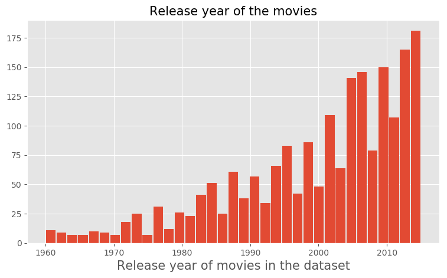

```python
#plotting a histogram of runtime of movies

#giving the figure size(width, height)
plot.figure(figsize=(9,5), dpi = 100)

#On x-axis
plot.xlabel('Release year of movies in the dataset', fontsize = 15)

#Name of the graph
plot.title('Release year of the movies', fontsize=15)

#giving a histogram plot
plot.hist(blockbusters['release_year'], rwidth = 0.9, bins =35)
#displays the plot
plot.show()
```

X axis represents the release year of the movies. This graph clearly depicts that No of movies increased gradually through the years.

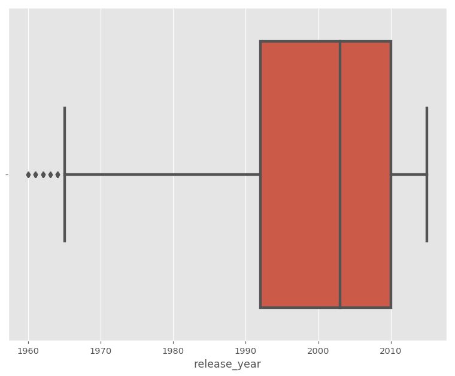

```python
#The First plot is box plot of the runtime of the movies
plot.figure(figsize=(9,7), dpi = 105)

#using seaborn to generate the boxplot
sb.boxplot(blockbusters['release_year'], linewidth = 3)
#diplaying the plot
plot.show()
```

X axis represents the release year of the movies. From the above graph we found that there are 5 outlier points in the graph and this graph is skewed to the left

# Successfull movies with respect to runtime before 2000

```python
blockbusters[(blockbusters.release_year < 2000 )].sort_values(by=['runtime'],ascending=False).head()
```

|  | popularity | profit | budget | revenue | original_title | cast | director | keywords | runtime | genres | production_companies | release_date | vote_count | vote_average | release_year |
| --- | --- | --- | --- | --- | --- | --- | --- | --- | --- | --- | --- | --- | --- | --- | --- |
| 1782 | 1.168767 | 55000000.0 | 15000000.0 | 70000000.0 | Lawrence of Arabia | Peter O'Toole\|Alec Guinness\|Anthony Quinn\|Jack... | David Lean | cairo\|arabian\|world war i\|horse\|jerusalem | 216 | Adventure\|Drama\|History\|War | Horizon Pictures (II) | 2062-12-10 | 517 | 7.5 | 1962 |
| 1761 | 3.264571 | 34542841.0 | 13000000.0 | 47542841.0 | The Godfather: Part II | Al Pacino\|Robert Duvall\|Diane Keaton\|Robert De... | Francis Ford Coppola | italo-american\|cuba\|vororte\|melancholy\|praise | 200 | Drama\|Crime | Paramount Pictures\|The Coppola Company | 1974-12-20 | 2131 | 8.1 | 1974 |
| 1843 | 1.136943 | 48000000.0 | 12000000.0 | 60000000.0 | Spartacus | Kirk Douglas\|Laurence Olivier\|Jean Simmons\|Cha... | Stanley Kubrick | gladiator\|roman empire\|gladiator fight\|slavery... | 197 | Action\|Drama\|History | Bryna Productions | 2060-10-06 | 211 | 6.9 | 1960 |
| 1956 | 1.282053 | 97721910.0 | 14000000.0 | 111721910.0 | Doctor Zhivago | Omar Sharif\|Julie Christie\|Geraldine Chaplin\|R... | David Lean | love triangle\|nurse\|suicide attempt\|loss of fa... | 197 | Drama\|Romance\|War | Metro-Goldwyn-Mayer (MGM) | 2065-12-22 | 126 | 6.9 | 1965 |
| 1861 | 2.377288 | 299265768.0 | 22000000.0 | 321265768.0 | Schindler's List | Liam Neeson\|Ben Kingsley\|Ralph Fiennes\|Carolin... | Steven Spielberg | factory\|concentration camp\|hero\|holocaust\|worl... | 195 | Drama\|History\|War | Universal Pictures\|Amblin Entertainment | 1993-11-29 | 2632 | 8.1 | 1993 |

# # Successfull movies with respect to runtime after 2000

```python
blockbusters[(blockbusters.release_year >= 2000 )].sort_values(by=['runtime'],ascending=False).head()
```

|  | popularity | profit | budget | revenue | original_title | cast | director | keywords | runtime | genres | production_companies | release_date | vote_count | vote_average | release_year |
| --- | --- | --- | --- | --- | --- | --- | --- | --- | --- | --- | --- | --- | --- | --- | --- |
| 792 | 7.122455 | 1.024889e+09 | 94000000.0 | 1.118889e+09 | The Lord of the Rings: The Return of the King | Elijah Wood\|Ian McKellen\|Viggo Mortensen\|Liv T... | Peter Jackson | elves\|orcs\|middle-earth (tolkien)\|based on nov... | 201 | Adventure\|Fantasy\|Action | WingNut Films\|New Line Cinema | 2003-12-01 | 5636 | 7.9 | 2003 |
| 1034 | 1.508329 | 3.430000e+08 | 207000000.0 | 5.500000e+08 | King Kong | Naomi Watts\|Jack Black\|Adrien Brody\|Thomas Kre... | Peter Jackson | film business\|screenplay\|show business\|film ma... | 187 | Adventure\|Drama\|Action | WingNut Films\|Universal Pictures\|Big Primate P... | 2005-12-14 | 1289 | 6.4 | 2005 |
| 400 | 2.478879 | 3.092209e+08 | 140000000.0 | 4.492209e+08 | Pearl Harbor | Ben Affleck\|Josh Hartnett\|Kate Beckinsale\|Cuba... | Michael Bay | nurse\|patriotism\|hawaii\|world war ii\|pilot | 183 | History\|Romance\|War | Jerry Bruckheimer Films\|Touchstone Pictures | 2001-05-21 | 1044 | 6.6 | 2001 |
| 521 | 0.215030 | 6.690000e+07 | 9100000.0 | 7.600000e+07 | Ghajini | Aamir Khan\|Asin Thottumkal\|Jiah Khan\|Pradeep R... | A.R. Murugadoss | tattoo\|short-term memory | 183 | Action\|Drama\|Foreign\|Mystery\|Thriller | NaN | 2008-12-25 | 53 | 6.9 | 2008 |
| 903 | 4.877927 | 2.920007e+08 | 100000000.0 | 3.920007e+08 | The Wolf of Wall Street | Leonardo DiCaprio\|Jonah Hill\|Margot Robbie\|Kyl... | Martin Scorsese | corruption\|sex\|sexuality\|bank\|humor | 180 | Crime\|Drama\|Comedy | Paramount Pictures\|Appian Way\|EMJAG Production... | 2013-12-25 | 4027 | 7.9 | 2013 |

### Successfull genres with respect to their profit before and after 2000

```python
drama1=blockbusters[(blockbusters.release_year <= 2000) & (blockbusters.genres=='Drama') ]
drama2=blockbusters[(blockbusters.release_year > 2000 ) & (blockbusters.genres=='Drama')  ]
comedy1=blockbusters[(blockbusters.release_year <= 2000) & (blockbusters.genres=='Comedy') ]
comedy2=blockbusters[(blockbusters.release_year > 2000) & (blockbusters.genres=='Comedy') ]
action1=blockbusters[(blockbusters.release_year <= 2000) & (blockbusters.genres=='Action') ]
action2=blockbusters[(blockbusters.release_year > 2000) & (blockbusters.genres=='Action') ]
thriller1=blockbusters[(blockbusters.release_year <= 2000) & (blockbusters.genres=='Thriller') ]
thriller2=blockbusters[(blockbusters.release_year >= 2000) & (blockbusters.genres=='Thriller') ]
```

# Profitability of Drama Movies Before 2000

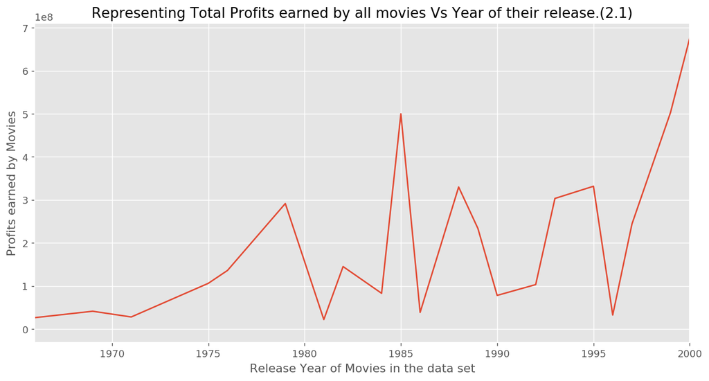

```python
drama1_graph = drama1.groupby('release_year')['profit'].sum()

#figure size(width, height)
plot.figure(figsize=(12,6), dpi = 130)

#on x-axis
plot.xlabel('Release Year of Movies in the data set', fontsize = 12)
#on y-axis
plot.ylabel('Profits earned by Movies', fontsize = 12)
#title of the line plot
plot.title('Representing Total Profits earned by all movies Vs Year of their release.(2.1)')

#plotting the graph
plot.plot(drama1_graph)
#plot.xlim(1966 to 2000)
plot.xlim(1966,2000)
#plot.xlim(1966 to 2000)

#displaying the line plot
plot.show()
```

# Profitability of Drama movies after 2000

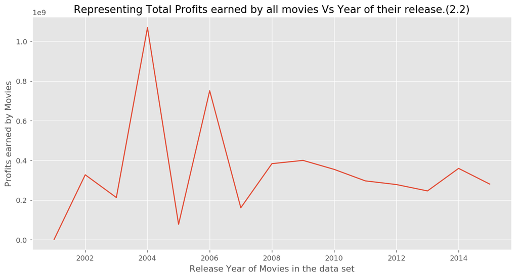

```python
drama2_graph = drama2.groupby('release_year')['profit'].sum()

#figure size(width, height)
plot.figure(figsize=(12,6), dpi = 130)

#on x-axis
plot.xlabel('Release Year of Movies in the data set', fontsize = 12)
#on y-axis
plot.ylabel('Profits earned by Movies', fontsize = 12)
#title of the line plot
plot.title('Representing Total Profits earned by all movies Vs Year of their release.(2.2)')

#plotting the graph
plot.plot(drama2_graph)

#displaying the line plot
plot.show()
```

X axis represents the Release Year and Y axis represents the profits earned by the movies in particular year. From the above graph we can deduce that growth has dropped gradually after 20066. on comparing previous grapth we can conclude that movies made more profit from the year 2000 than before.

# Profitability of Comedy movies before 2000

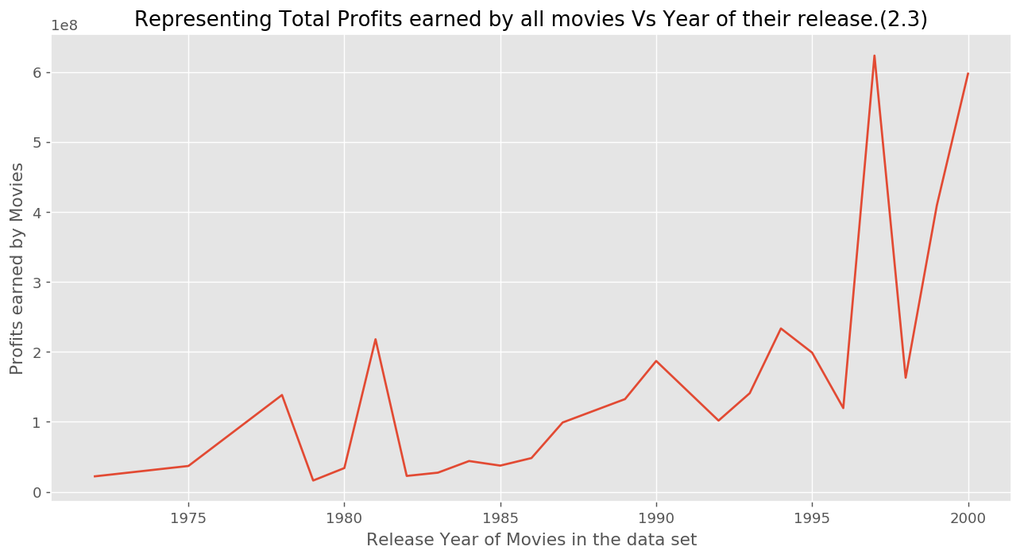

```python
comedy1_graph = comedy1.groupby('release_year')['profit'].sum()

#figure size(width, height)
plot.figure(figsize=(12,6), dpi = 130)

#on x-axis
plot.xlabel('Release Year of Movies in the data set', fontsize = 12)
#on y-axis
plot.ylabel('Profits earned by Movies', fontsize = 12)
#title of the line plot
plot.title('Representing Total Profits earned by all movies Vs Year of their release.(2.3)')

#plotting the graph
plot.plot(comedy1_graph)

#displaying the line plot
plot.show()
```

X axis represents the Release Year and Y axis represents the profits earned by the movies in particular year. From the above graph we can deduce that profit has risen gradually through the years.

# Profitability of Comedy movies after 2000

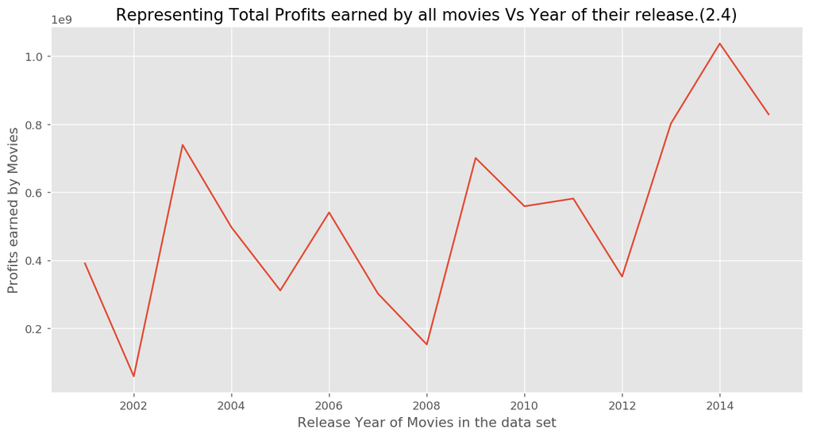

```python
comedy2_graph = comedy2.groupby('release_year')['profit'].sum()

#figure size(width, height)
plot.figure(figsize=(12,6), dpi = 130)

#on x-axis
plot.xlabel('Release Year of Movies in the data set', fontsize = 12)
#on y-axis
plot.ylabel('Profits earned by Movies', fontsize = 12)
#title of the line plot
plot.title('Representing Total Profits earned by all movies Vs Year of their release.(2.4)')

#plotting the graph
plot.plot(comedy2_graph)

#displaying the line plot
plot.show()
```

X axis represents the Release Year and Y axis represents the profits earned by the movies in particular year. From the above graph we can say that profit peaked in 2014.

# Profitability of Thriller movies before 2000

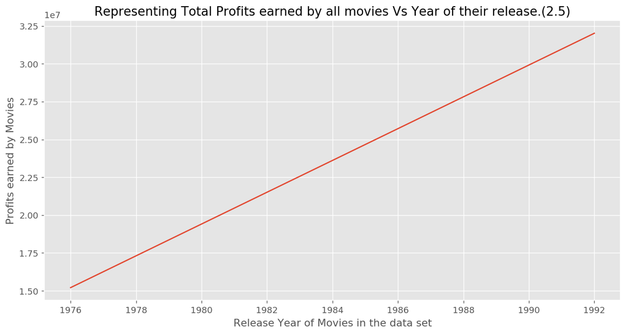

```python
thriller1_graph = thriller1.groupby('release_year')['profit'].sum()

#figure size(width, height)
plot.figure(figsize=(12,6), dpi = 130)

#on x-axis
plot.xlabel('Release Year of Movies in the data set', fontsize = 12)
#on y-axis
plot.ylabel('Profits earned by Movies', fontsize = 12)
#title of the line plot
plot.title('Representing Total Profits earned by all movies Vs Year of their release.(2.5)')

#plotting the graph
plot.plot(thriller1_graph)

#displaying the line plot
plot.show()
```